# filter-rplot.tcl documentation

Detlef Groth, Caputh-Schwielowsee, Germany

Nov 30, 2024

filter-abc - filter-cmd - filter-dot - filter-emf - filter-eqn - filter-julia - filter-kroki - filter-mmd - filter-mtex - filter-pic/dpic - filter-pik  
filter-pipe - filter-puml - filter-rplot - filter-sqlite - filter-tcrd - filter-tcl - filter-tdot - filter-tsvg

Documentation: Pantcl filter documentation - Pantcl tutorial - Pantcl Readme - Pantcl Gui

## Name

*filter-rplot.tcl* - Filter which can be used to display R plots within a Pandoc processed document using the Tcl filter driver `pantcl.bin`.

## Usage

The conversion of the Markdown documents via Pandoc should be done as follows:

```
pandoc input.md --filter pantcl.bin -s -o output.html
```

The file `filter-rplot.tcl` is not used directly but sourced automatically by the `pantcl.bin` file. If code blocks with the `.rplot` marker are found, the contents in the code block is processed via the Rscript interpreter if the chunk option `eval` is set to true or 1. If the interpreter is not in the PATH you might add the application path in your YAML header as shown below.

To change the defaults the YAML header can be used. Here an example to change the default Rscript interpreter, the image output path to nfigures and the file extension to pdf (useful for Pdf output of the document). Please note that in the YAML header you can only use 0 or 1 instead of false and true.

```
 ----
 title: "filter-rplot.tcl documentation"
 author: "Detlef Groth, Caputh-Schwielowsee, Germany"
 date: 2021-11-29
 rplot:
     app: /path/to/Rscript
     imagepath: nfigures
     ext: pdf
     eval: 1
 ----
```

## Examples

Here an example for a pairsplot graph:

````
     ```{.rplot eval=true}
     data(iris)
     pairs(iris[,1:3],col=as.numeric(iris$Species)+1,pch=19)
     ```
````

And here is the output:

```
data(iris)
pairs(iris[,1:3],col=as.numeric(iris$Species)+1,pch=19)
```

```
null device
          1
```

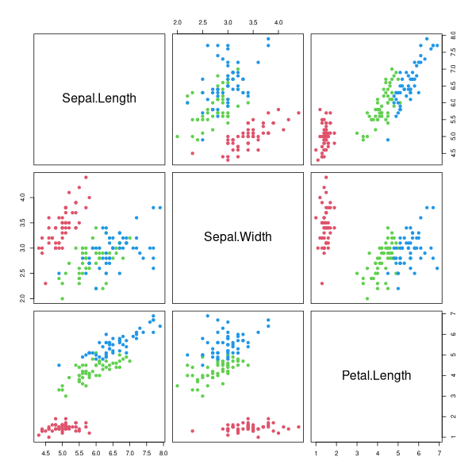

To supress the message line you can add results=“hide” as chunk option like this: `{.rplot results="hide"}`

```
boxplot(iris$Sepal.Length ~ iris$Species,col=2:4)
```

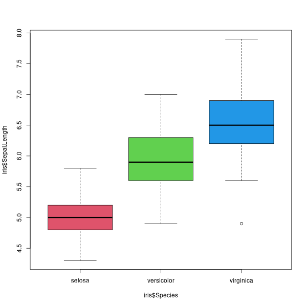

## See also:

- pantcl Readme
- Pipe filter for R, Python, Octave